# Group_05_Analysis: Prevelance of Obesity in Scotland (2013-2016)

*Group 5: Chloe Au Yeung, Xinyan Tian, Cameron Fraser, and Sarah Khan*

# Introduction

## Data Overview

In this report, we will begin using logistic regression to model outcomes of interest that take one of two categorical values. Then, we will use model diagnostics to assess if this model is the most reliable and fits the data best. Then we will look at the `DAProject.csv` dataset which contains the socio-economic and lifestyle factors from the 2013 - 2016 Scottish Health Surveys.

- `Age` - Age of individual,
- `Sex` - Sex of individual (Male/ Female),
- `Education` - Highest educational qualification of individual,
- `Veg` - Consume recommended daily vegetable intake (Yes / No),
- `Fruit` - Consume recommended daily fruit intake (Yes / No),
- `Year` - Year of the Scottish Health Survey,
- `Obese` - Indicator of individuals obesity classification (Yes / No).

Since this dataset contains a binary categorical variable `Obese` - classified as `Yes`/`No` - logistic regression may be considered as an appropriate modelling approach. The main questions of interest are:

- Has the prevalence of obesity in Scotland changed over the given years of the Scottish Health Survey?
- Are there any differences in obesity by age, gender, socio-economic status, or lifestyle factors?

# Explanatory Data Analysis

## Logistic Regression

Logistic regression is used when the outcome of interest takes one of two categorical values (e.g. `Yes`/`No`). In this case, the response variable takes the value 1 (defined as success, with probability $p_i$) or 0 (defined as failure, with probability $1 - p_i$). And the response is given by $Y_i$ with Bernoulli distribution. The corresponding model uses the logit link function:
$$g(p_i) =
\log\left(\frac{p_i}{1 - p_i}\right)
= \log\left(\frac{\mathbb{P}(Y_i = 1 \mid \underline{x}_i)}{\mathbb{P}(Y_i = 0 \mid \underline{x}_i)}\right)
= \underline{x}_i^\top \underline{\beta}
\tag{1}$$

We can refer to Equation 1 as the log-odds, since $\frac{p_i}{1 - p_i}$ represents the odds. Taking the inverse of the logit link function gives the following:
$$\mathbb{P}(Y_i = 1 \mid \underline{x}_i)
= \frac{\exp(\underline{x}_i^\top \underline{\beta})}{1 + \exp(\underline{x}_i^\top \underline{\beta})}
\tag{2}$$
$$\mathbb{P}(Y_i = 0 \mid \underline{x}_i)
= \frac{1}{1 + \exp(\underline{x}_i^\top \underline{\beta})}.
\tag{3}$$

## Visualisations

To get an initial impression of the data set, we will look at the binary categorical variable `Obese` as our response variable.

#### Year vs prevalence

Table 1: Prevalence of obesity over 2013-2016

| Year | Prevalence(%) |
| --- | --- |
| 2013 | 30.301 |
| 2014 | 30.182 |
| 2015 | 30.645 |
| 2016 | 30.536 |

We can look at a bar plot of the proportion of `Obese` by `Year` to observe if there are changes in prevalence across the years.

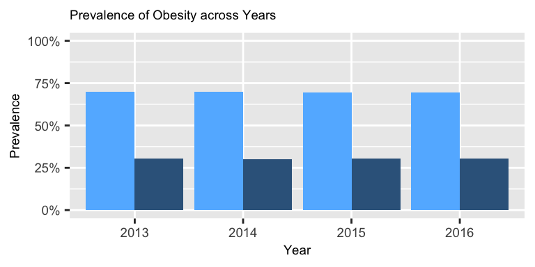

Figure 1: Prevalence of Obesity across 2013–2016

We can see in Figure 1 that there was an approximate consistency in proportion of individuals in the `Yes` obesity group. From Table 1, the proportion of individuals in the `Yes` obesity group appears, on average, at 30.5%.

#### Sex vs prevalence

Table 2: Prevalence of obesity by sex

| Sex | Prevalence(%) |
| --- | --- |
| Female | 31.463 |
| Male | 29.094 |

In Table 2, we can see that females in the `Yes` obesity group tends to be slightly higher than that of males.

#### Age vs prevalence

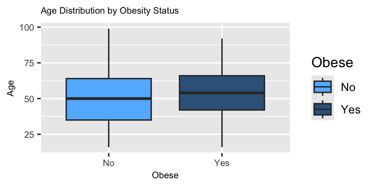

Figure 2: Age Distribution by Obesity Status

Figure 2 shows the distribution of age by obesity status. Individuals classified as obese tends to have slightly higher median ages compared to non-obese individuals.

#### Education vs prevalence

Table 3: Prevalence of obesity by education level

| Education | Prevalence(%) |
| --- | --- |
| Degree or higher | 24.712 |
| Higher grade or equiv | 28.166 |
| HNC/D or equiv | 31.313 |
| No qualifications | 38.170 |
| Other school level | 35.518 |
| Standard grade or equiv | 32.899 |

From Table 3, proportion of individuals in the `Yes` obesity group variably increases across education levels. For example, individuals in the `No Qualifications` group have a higher prevalence of obesity (38.2%), than those in the `Degree of higher` group (24.7%).

#### Vegetable Intake

Table 4: Prevalence of obesity by Vegetable intake

| Vegetable_intake | Prevalence(%) |
| --- | --- |
| No | 32.560 |
| Yes | 29.792 |

#### Fruits Intake

Table 5: Prevalence of obesity by Fruit intake

| Fruit_intake | Prevalence(%) |
| --- | --- |
| No | 30.294 |
| Yes | 30.466 |

Additionally, Table 4 and Table 5 displays similar results for nutritional consumption `Yes`/`No` with the `Fruit` group intake being approximately the same and the `No` `Vegetable` intake group having a larger proportion (32.6% vs 29.8%).

# Formal Data Analysis

## Model Specification

We will now fit a logistic model to investigate the relationship between obesity and explanatory variables. Let $Y_i = 1$ if individual *i* is obese and $Y_i = 0$ otherwise. We will assume that:
$$Y_i \sim \text{Bernoulli}(p_i)$$
where, $p_i = \mathbb{P}(Y_i = 1 \mid \underline{x}_i)$ and $Y_i = Obese_i$. The model is given by:
$$logit(p_i)=\alpha_0 + \beta_1 \,\mathbb{I}_{(\text{Year}_i = 2014)}
+ \beta_2 \,\mathbb{I}_{(\text{Year}_i = 2015)}
+ \beta_3 \,\mathbb{I}_{(\text{Year}_i = 2016)} \tag{4}$$

where: 2013 is the reference year. The intercept $\alpha_0$ represents the log-odds of an individual being obese in the reference year 2013, and the coefficients $\beta_1$, $\beta_2$, $\beta_3$ represent the change in log-odds in each year compared to 2013.

To fit a logistic regression model, we will conduct variable selection using a backwards elimination approach, supported by model selection critera such as Bayesian Information Criterion (BIC) and likelihood ratio test. The performance of the model we select will be assessed using the Receiver Operating Characteristic (ROC) Curve.

## Results

#### Year vs prevalence

We will fit a logistic regression model using the logit link function, with `Obese` as the response and `Year` as the explanatory variable:

Table 6: Coefficient of the logistic regression model

|  | Obese |  |  |
| --- | --- | --- | --- |
| Predictors | Log-Odds | CI | p |
| (Intercept) | -0.83 | -0.90 – -0.76 | **<0.001** |
| Year [2014] | -0.01 | -0.11 – 0.09 | 0.913 |
| Year [2015] | 0.02 | -0.08 – 0.12 | 0.749 |
| Year [2016] | 0.01 | -0.09 – 0.11 | 0.832 |
| Observations | 14017 |  |  |
| R<sup>2</sup> Tjur | 0.000 |  |  |

The coefficients for all years appear close to zero. Additionally, the confidence intervals across all years include zero and p > 0.05. This provides no evidence that year is a statistically significant predictor of obesity, which suggests that obesity prevalence has not changed over time. We can visualise the probabilities using the plot_model() function as follows:

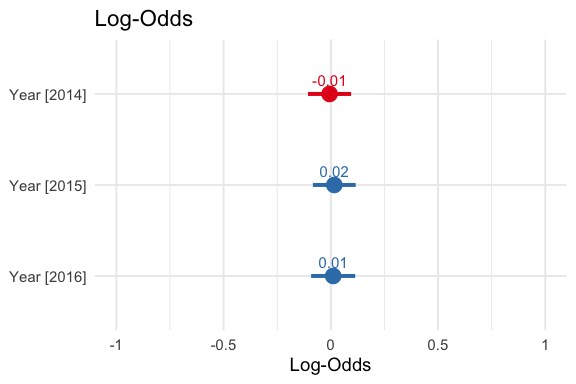

Figure 3: Coefficient of the Logistic Regression Model

Figure 3 shows the estimated log-odds coefficients for each year relative to the reference category (2013) are all close to zero, and their confidence intervals include zero. This indicates that there is minimal difference in log-odds of obesity across years. Adding onto this, Table 6 shows large p-values, which further provides evidence that year is not a statistically significant predictor of obesity. Comparing coefficients of the regression model with that of the reference level appears to be approximately the same. We can now obtain probability predictions for each year using the `predict()` function as follows:

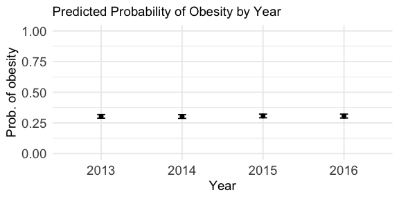

Figure 4: Prob. of Obesity by Year

From Figure 4, we can predict the probability of obesity for each year. The probabilities appear to be constant at approximately 30%, with the confidence intervals overlapping. This, again, indicates that there is no significant change in obesity prevalence over time.

#### Comparison: Full Model vs. Reduced Model (with fruit intake removed)

We now investigate whether obesity differs by age, gender, socio-economic status, and lifestyle factors. By this, we will fit a full model including variables `Age`, `Sex`, `Education`, `Veg`, and `Fruit`. Our full model indicates that fruit intake is not a statistically significant predictor for obesity due to the large p-value (0.942) so it is removed. As seen in the reduced model, and to compare models we also fit a reduced model, with `Fruit` removed:

Table 7: Model comparison

|  | Reduced Model |  |  | Full Model |  |  |
| --- | --- | --- | --- | --- | --- | --- |
| Predictors | Log-Odds | CI | p | Log-Odds | CI | p |
| (Intercept) | -1.52 | -1.67 – -1.37 | **<0.001** | -1.52 | -1.68 – -1.37 | **<0.001** |
| Age | 0.01 | 0.01 – 0.01 | **<0.001** | 0.01 | 0.01 – 0.01 | **<0.001** |
| Sex [Male] | -0.12 | -0.20 – -0.05 | **0.001** | -0.12 | -0.20 – -0.05 | **0.001** |
| Education [Higher grade or equiv] | 0.23 | 0.11 – 0.34 | **<0.001** | 0.23 | 0.11 – 0.34 | **<0.001** |
| Education [HNC/D or equiv] | 0.36 | 0.23 – 0.48 | **<0.001** | 0.36 | 0.23 – 0.48 | **<0.001** |
| Education [No qualifications] | 0.46 | 0.35 – 0.58 | **<0.001** | 0.46 | 0.35 – 0.58 | **<0.001** |
| Education [Other school level] | 0.31 | 0.14 – 0.48 | **<0.001** | 0.31 | 0.14 – 0.48 | **<0.001** |
| Education [Standard grade or equiv] | 0.42 | 0.31 – 0.53 | **<0.001** | 0.42 | 0.31 – 0.53 | **<0.001** |
| Veg [Yes] | -0.10 | -0.19 – -0.02 | **0.021** | -0.10 | -0.19 – -0.01 | **0.023** |
| Fruit [Yes] |  |  |  | 0.00 | -0.08 – 0.09 | 0.942 |
| Observations | 14017 |  |  | 14017 |  |  |
| R<sup>2</sup> Tjur | 0.018 |  |  | 0.018 |  |  |

In summary, due to the insignificant p-value, we can remove fruit intake from the full model. The reduced model predictors are now all statistically significant. Next, we will compare the BIC of the reduced model again the full model to supplement this conclusion:

Table 8: Model BIC comparison

| Name | Model | BIC | BIC_wt |
| --- | --- | --- | --- |
| reduced_model | glm | 17050.38 | 0.9916024 |
| full_model | glm | 17059.92 | 0.0083976 |

The full model has a higher BIC in comparison to the reduced model, indicating a poorer balance between model fit and complexity. As a result, the reduced model is preferred. In addition to this, we can conduct a likelihood ratio test:

Table 9: Model likelihood ratio test

| Resid. Df | Resid. Dev | Df | Deviance | Pr(>Chi) |
| --- | --- | --- | --- | --- |
| 14008 | 16964.45 | NA | NA | NA |
| 14007 | 16964.44 | 1 | 0.0052782 | 0.9420837 |

A likelihood ratio test comparing the reduced and full models yields a p-value of 0.94. Since this is greater than 0.05, there is no evidence that the additional predictor, fruit intake, improve model fit.

#### Model check

We will now investigate diagnostic plots to assess how well the model fits the data. This way we can assess whether our assumptions are met:

Table 10

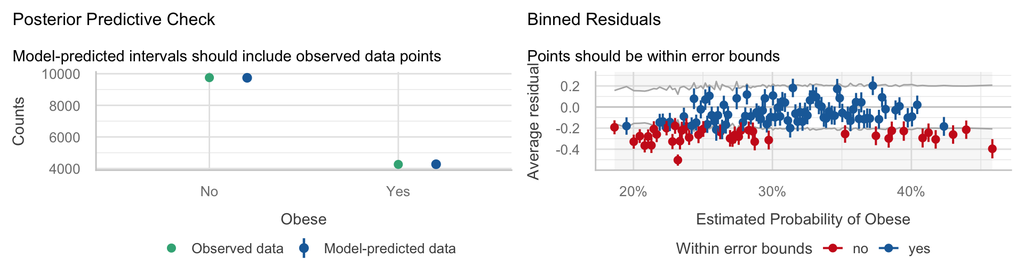

Posterior predictive check and binned residuals for the reduced model

Table 11

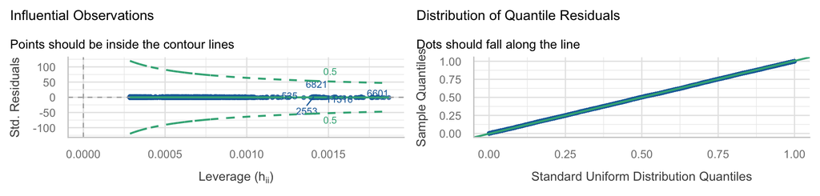

Influential observations and quantile residuals for the reduced model

Finally, we will assess the performance of the model using the Receiver Operating Characteristic (ROC) Curve:

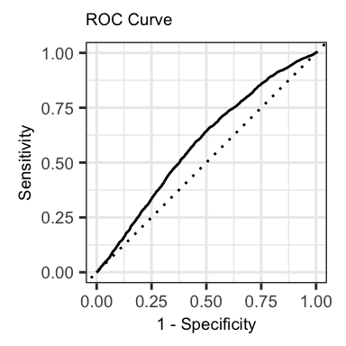

Figure 5: ROC Curve

The ROC curve in Figure 5 indicates if the model was able to distinguish between obese and non-obese individuals. Since the curve appears to be close to the diagonal line, this indicates the model only performs slightly better than guessing at random. The area under the curve (AUC) is approximately 0.60, which suggests a moderate-poor predictive performance. This indicates that, although several predictors are statistically significant, the effect they have are not strong.

# Discussion

# Conclusion

In conclusion, there is no suggested evidence that obesity prevalence has any significant chance over the years we considered in this report. Moreover, there was evidence of a difference in obesity by age, gender, socio-economic status, or vegetable consumption, however, no evidence of a difference was observed by fruit.

# Reference

Scottish Government (2013-2016). *Scottish Health Survey.*